# Estimation of dispersal distances of the obligately plant‐associated ant Crematogaster decamera - TÜRKE - 2010 - Ecological Entomology - Wiley Online Library

[Ecological Entomology](https://resjournals.onlinelibrary.wiley.com/journal/13652311)

[Volume 35, Issue 5](https://resjournals.onlinelibrary.wiley.com/toc/13652311/2010/35/5) p. 662-671

[figure not shown]

Free Access

# Estimation of dispersal distances of the obligately plant-associated ant *Crematogaster decamera*

[MANFRED TÜRKE](https://resjournals.onlinelibrary.wiley.com/action/doSearch?ContribAuthorRaw=T%C3%9CRKE%2C+MANFRED),

[BRIGITTE FIALA](https://resjournals.onlinelibrary.wiley.com/action/doSearch?ContribAuthorRaw=FIALA%2C+BRIGITTE),

[KARL EDUARD LINSENMAIR](https://resjournals.onlinelibrary.wiley.com/action/doSearch?ContribAuthorRaw=LINSENMAIR%2C+KARL+EDUARD),

[HEIKE FELDHAAR](https://resjournals.onlinelibrary.wiley.com/action/doSearch?ContribAuthorRaw=FELDHAAR%2C+HEIKE),

Heike Feldhaar, Behavioural Biology, School of Biology/Chemistry, University of Osnabrück, Barbarastr. 11, D-49076 Osnabrück, Germany. E-mail:

First published: 21 July 2010

https://doi.org/10.1111/j.1365-2311.2010.01222.x

Citations: 12

## Abstract

1. In obligate symbioses with horizontal transmission, the population dynamics of the partner organisms are highly interdependent. Host population size limits symbiont number, and distribution of partners is restricted by the presence and thus dispersal abilities of their respective partner. The *Crematogaster decamera*–*Macaranga hypoleuca* ant–plant symbiosis is obligate for both partners. Host survival depends on colonisation by its ant partner while foundress queens require hosts for colony establishment.

2. An experimental approach and population genetic analyses were combined to estimate dispersal distances of foundresses in their natural habitat in a Bornean primary rainforest.

3. Colonisation frequency was significantly negatively correlated with distance to potential reproductive colonies. Results were similar for seedlings at natural densities as well as for seedlings brought out in the area experimentally. Population genetic analysis revealed significant population differentiation with an F<sub>ST</sub> of 0.041 among foundresses (*n* = 157) located at maximum 2280 m apart. In genetic spatial autocorrelation, genotypes of foundresses were significantly more similar than expected at random below 550 m and less similar above 620 m. Direct estimation of dispersal distances by pedigree analysis yielded an average dispersal distance of 468 m (maximum 1103 m).

4. For ants that disperse on the wing, genetic differentiation at such small spatial scales is unusual. The specific nesting requirements of the queens and the necessity for queens to find a host quickly could lead to colonisation of the first suitable seedling encountered, promoting short dispersal distances. Nonetheless, dispersal distances of *C. decamera* queens may vary with habitat or host spatial distribution.

## Introduction

Obligate interspecific interactions range from antagonistic, such as specific parasitoids and their hosts, to mutualistic interactions that are reciprocally beneficial to the organisms involved. In contrast to antagonistic interactions, where host fitness can be enhanced by escape from parasites in a fragmented landscape (Green, 2009), fitness of interacting individuals in obligate mutualistic interactions may be tightly linked to the presence (and fitness) of the partner species within the same habitat patch. Interdependence of partners may vary though, depending on the degree of specificity of the interaction. Associations may be obligate to only one of the partners involved or the range of possible partners may be wider for one of the partners (Fonseca & Ganade, 1996; Blüthgen *et al.*, 2007). In mutualistic symbiotic interactions with horizontal transmission, partners disperse independently but need to come together anew in each generation. When the presence of the respective partner species is required for survival and reproduction, the demography and dispersal abilities of each species will strongly affect its partner species (Tscharntke & Brandl, 2004).

A prominent example of an obligate interspecific mutualism with independent dispersal of the partner organisms is ant–plant mutualism. In one of the most species-rich ant–plant symbiotic associations worldwide, approximately 30 species of pioneer trees of the genus *Macaranga* (Euphorbiaceae) are obligately associated with specific partner ants, mostly by eight species of *Crematogaster* ants (subgenus *Decacrema*) (Fiala *et al.*, 1999; Blattner *et al.*, 2001; Davies *et al.*, 2001; Feldhaar *et al.*, 2003a; Bänfer *et al.*, 2004; Quek *et al.*, 2007). The associations of ants and plants are not strictly species-specific. Nonetheless, recurring association patterns between the two groups can be observed over a wide geographical range (Fiala *et al.*, 1999; Feldhaar *et al.*, 2003b).

In these mutualistic associations, the ants defend the trees against herbivores and vines (Fiala *et al.*, 1994; Heil *et al.*, 2001, Federle *et al.*, 2002) in return for nesting space in the hollow stems of the hosts and food in the form of food-bodies and extrafloral nectar (Fiala *et al.*, 1989). The ants rely exclusively on the food provided by the host plant (Fiala & Maschwitz, 1992; Heil *et al.*, 1997) and have, to date, never been found nesting or foraging away from their hosts. In contrast, hosts can survive short periods in their natural habitat without ant-protection. As a seedling, each host needs to reach a certain size before it can be colonised by a queen, and larger trees will often survive the loss of an ant-partner until they are recolonised (Feldhaar *et al.*, 2003b). The number of hosts present in a given habitat patch poses an upper limit to the abundance of the specific partner ants, as each host usually houses only a single ant colony.

Ants and plants reproduce and disperse independently and may differ in their ability to disperse. The ant-associated *Macaranga* are mostly pollinated by thrips, likely facilitating long-distance gene flow through wind drift (Moog *et al.*, 2002; Bänfer *et al.*, 2006) and seeds are dispersed by birds or small mammals (Whitmore, 1969; B. Fiala, pers. obs.). The ants disperse via winged sexuals. Similar to most other ant species, the dispersal distances of the ants are unknown, like for most other ant species. However, as flying is energetically costly, winged sexuals are rarely expected to disperse more than a few kilometres away from their natal colony (Vogt *et al.*, 2000).

The original habitat of light-demanding *Macaranga* species in South-East Asia seems to be forest gaps as well as forest edges and stream banks (Whitmore, 1969). In gaps of primary forest, one usually finds only a few or no seedlings, although in rare cases there may be several hundred at a time if a large gap opens up near a reproductive tree; however, the density of seedlings may be much larger in disturbed secondary forests (Davies *et al.*, 1998; H. Feldhaar and B. Fiala, pers. obs.). Population dynamics of the highly specialized partner ants should be strongly dependent on the spatial distribution of the host, especially when hosts are patchily distributed such as in primary forest habitats. We expect that finding a suitable and uncolonised host in such habitats is difficult when the number of hosts present is very small. In addition, searching for a host becomes increasingly costly for ant queens with increasing distance from their natal colony, as metabolic costs and risk of predation will rise with longer flight distances and more time spent outside a sheltering host. In turn, as hosts require to be colonised by their specific partner ants as a biotic defence agent at a very early stage, hosts can only establish successfully in habitat patches that are within dispersal distance of foundress queens. Thus dispersal ability of the ants will also limit host distribution and dispersal.

Here dispersal distances of the obligately plant-associated ant *Crematogaster (Decacrema) decamera* in a primary forest habitat were estimated (i) indirectly by measuring colonisation rates of foundresses on seedlings in relation to the distance of potential natal colonies, and (ii) directly by assigning individual foundresses to their natal colonies based on multilocus genotypes. Experimental results are compared to the natural distribution of foundresses in relation to potential natal colonies. The impact of spatial distribution of the host *Macaranga hypoleuca* on the genetic population structure of its specific ant partner is discussed.

## Materials and methods

### Crematogaster decamera–Macaranga hypoleuca *association*

Symbiotic associations commence with foundress queens of *Crematogaster* (*Decacrema*) *decamera* (Forel) colonising swollen internodia on seedlings of the host plant *Macaranga hypoleuca* (Reichb. F. & Zoll.) Muell. Arg (Euphorbiaceae). Ant colonies increase in size along with the growth of the plant and thus increasing nesting space of their host. *Crematogaster decamera* colonies produce sexuals when they are still relatively small [approximately 600 workers (Feldhaar *et al.*, 2003b)], thereafter sexuals are usually always present within colonies. Foundresses of *C. decamera* colonise seedlings all year round (H. Feldhaar and B. Fiala, pers. obs.). These colonies dominate young trees only and for several years. Abandoned trees are colonised by other ant species, mainly *Crematogaster (Decacrema)* morphospecies 1 (Fiala *et al.*, 1999; Feldhaar *et al.*, 2003a,b). Seedlings often occur clumped in forest gaps and sometimes single individuals are found within gaps (called ‘sites’ hereafter, Table 1). Mature trees may occur in the vicinity of such gaps but usually show a more scattered distribution within the forest, presumably within former tree-fall gaps that are now closed and often too dark for development of seedlings.

Table 1. Number of naturally occurring seedlings per sampling site within the study area.

[output not shown]

- Colonisations: number of foundress queens summed over all seedlings within the site.
- Mean distance: mean distance to 20 potentially reproductive colonies mapped within the study area.

### Study area, host plant mapping, and ant collection

The present study was conducted in a primary dipterocarp lowland rainforest in Borneo (Sabah/Malaysia) on the eastern border of the Danum Valley Conservation Area. Disturbed forest is adjacent to the conservation area as a result of logging activities since the 1960s. On the rim of the conservation area, a grid of three east-west orientated trails each of 1.5 km length and four north-south trails each of 1 km length, marked at 100-m intervals, was established in the primary forest, with parallel trails being approximately 500 m apart from each other (‘West-grid’; Fig. 1A). Additional trails reached further into primary forest.

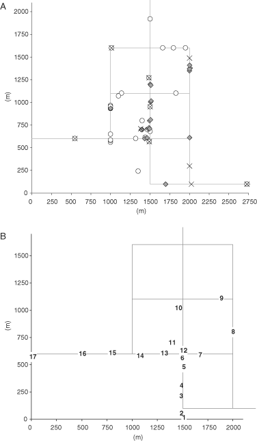

**Figure 1**

Open in figure viewer[PowerPoint](https://resjournals.onlinelibrary.wiley.com/action/downloadFigures?id=f1&doi=10.1111%2Fj.1365-2311.2010.01222.x)

Trails (approximately 19 km) were walked and searched for seedlings and trees of *M. hypoleuca* repeatedly from 9 March 2006 to 19 May 2006. Positions of *M. hypoleuca* individuals were estimated in reference to the closest trail and way point. In the core area (West-grid), *M. hypoleuca* individuals were also searched for within the forest adjacent to the trails. Exhaustive sampling of all potential mature trees in deeper forest was not possible because of the dense vegetation and therefore large parts of the forest were inaccessible. From a number of mapped trees that were relatively large, samples could not be obtained from the ground or even by climbing. Spatial distribution of seedlings was documented and ant queens from colonised seedlings collected (Table 1). Seedlings were scattered in the forest; each sampling locality of naturally occurring seedlings is called ‘sampling site’ hereafter. Foundress queens as well as workers, and when present, sexuals from older colonies in mature trees were collected and stored in 99% EtOH. In order to harm ant colonies as little as possible, we only collected one or a few branches of older *Macaranga* hosts. Ants were determined and could all be assigned to either *C. decamera* or *Crematogaster* msp. 1.

### Colonisation experiment

To test the hypothesis of whether the colonisation rate of seedlings decreases with increasing distance to colonies producing queens of *C. decamera*, a colonisation experiment was conducted. As of yet uncolonised seedlings of *M. hypoleuca* but which were suitable for colonisation (i.e. with at least one swollen unoccupied internodium) were collected outside the study area. Seedlings were planted in soil into well-drained plastic bags (15 × 15 cm) and kept in the shade at high humidity for 3 days before transfer to the forest. A total of 280 seedlings were positioned at one open site at the forest edge (plot 1), in one site at the edge of the primary forest in a cleared bamboo stand (plot 2) and in 15 natural gaps within primary forest (West-grid: plot 3–14 and Rhino Ridge Trail: plot 15–17; Fig. 1B). As most colonies of *C. decamera* that produced alates (*n* = 14) or were large enough to do so (*n* = 6) were found in the centre of the West-grid (Fig. 1A), plots were installed with increasing distance to the centre. Distance of the plots to the closest of any of the 20 colonies potentially containing alate females ranged from 5 to 1055 m (259 ± 244 m mean ± SD) and the mean distance of plots over all of the 20 colonies ranged from 390 to 1640 m (695 ± 330 m mean ± SD). The mean distance between a foundress collected from a seedling to all potential reproductive colonies was chosen as an estimate for its dispersal distance. It was assumed beforehand that all colonies were equally likely to release foundresses and that all seedlings may be colonised with equal probability.

In each plot the number of seedlings changed over time as some plants died and were replaced when new uncolonised seedlings were available. We therefore calculated the mean number of seedlings per plot available per day. The available number of seedlings per plot for 17 plots was 13.9 ± 3.7 (mean ± SD) and did not exceed maximal numbers of natural seedling aggregations in the study area. The mean number of seedlings with and without leaves, as several of the replanted seedlings lost leaves during the experimental period, was calculated (see supplementary material). Plots were checked for colonisations regularly (mean every 2.9 days) and plots without any colonisation were checked less frequently. Foundress queens of *C. decamera* gnaw an entrance hole to enter the hollow internode of their host plant. This entrance hole is subsequently closed again from the inside with the pith of the internode. Colonisation events can thereby be easily recognised and counted. The experiment lasted from 25 March 2006 to 19 May 2006 when all foundress queens that had colonised seedlings were collected. Uncolonised seedlings remained in the plots until 31 August 2006 and were then again checked for colonisations and foundress queens were collected. Data from the colonisation experiment were analysed with Statistica 7.0 (StatSoft, Inc., Tulsa, Oklahoma).

### DNA-extraction and amplification

Whole workers or whole virgin sexuals or the thoraces of foundress queens were ground in liquid nitrogen. DNA of four individuals from each potential reproductive colony (workers or sexuals that are full sisters to the workers) was extracted using the Puregene® DNA Purification Kit (Gentra Systems, Minnesota) according to the manufacturer's instructions. The DNA was resuspended in 30-µl Low-TE buffer for workers and 50 µl for queens and stored at −20 °C.

PCR amplification was performed in an Eppendorf Mastercycler® or Biometra T1 Thermocycler® in a total reaction volume of 12.5 µl containing approximately 10 ng of template DNA, 1× PCR-buffer, 2 mm MgCl<sub>2</sub>, 160 µm dNTPs, 2.5 µm of each primer (forward primer labelled with fluorescent IR-700 or IR-800dye) and 0.5 U of *Taq* DNA polymerase (*MolTaq*®; Molzym GmbH, Bremen, Germany). Five microsatellite loci were used: Ca5, Ca12, Ca18 (Feldhaar *et al.*, 2004), Crem6_2b and Crem6_5 [obtained using the same method described in Feldhaar *et al.* (2004)]. Cycle parameters were as follows: 3 min at 94 °C, followed by 30 cycles of 94 °C for 40 s, annealing step 40 s, 72 °C for 40 s, and a final extension of 3 min at 72 °C (see Table 2). PCR-products were diluted between 1:5 and 1:65 and analysed on a LICOR® 4300 DNA Analyzer (Lincoln, Nebraska).

Table 2. Characteristics of microsatellite loci for all genotyped foundresses.

[output not shown]

- T<sub>a</sub>, annealing temperature; N, number of foundresses genotyped; A, number of alleles; H<sub>O</sub>, observed heterozygosity; H<sub>E</sub>, expected heterozygosity.

### Population genetic analyses

Characteristics of the microsatellite markers in the ant population and tests of Hardy–Weinberg equilibrium (HWE) as well as isolation by distance based on subpopulations were calculated in Genepop On The Web (Raymond & Rousset, 1995; http://genepop.curtin.edu.au/). F-statistics (Weir & Cockerham, 1984) were performed in SPAGeDi 1.2 (Hardy & Vekemans, 2002). The significance of genetic differentiation (F<sub>ST</sub>) was tested in permutation tests (1000 permutations, corresponding to a 1% significance level) in SPAGeDI 1.2. A spatial genetic autocorrelation analysis was performed to examine the fine-scale spatial structure of the population of *C. decamera* with GenAlex 6.0 (Peakall & Smouse, 2006). The power of the genetic data to distinguish between genotypes similar by descent and similar by chance was estimated using the probability of identity (P<sub>ID</sub>) measure implemented in the program Gimlet (Valiére, 2002). Based on allele frequencies, the P<sub>ID</sub> gives the probability that two individuals are by chance genotyped identically and therefore determines the power of the microsatellite loci used in the study.

### Dispersal distances of foundresses

For direct estimates of dispersal distances, foundress queens of *C. decamera* from seedlings and workers from potential mother colonies were assigned to groups of full sibs based on their multilocus genotypes using the program Colony 1.2 (Wang, 2004). As there is no indication for multiple mating in *Crematogaster* (*Decacrema*) ants (Feldhaar *et al.*, 2005) and colonies are monogynous (Feldhaar *et al.*, 2003b), foundresses released from mother colonies are full sisters to the respective workers in such colonies. Typing- and scoring errors were set to 0.05. The program was run three times with different random generator seeds. Only individuals that were assigned to the same group in all three calculations, and could be assigned unambiguously as a full sib to all four genotyped workers of a single mother colony, were used for subsequent analyses. Furthermore, the distances between pairs of foundresses that were assigned to groups of full sibs were calculated, to see whether foundress queens from one colony disperse to the same or neighbouring sites or in different directions and distances.

## Results

### Natural host plant distribution

In an area of about 5 km<sup>2</sup>, 68 *M. hypoleuca* trees (>3 m) were mapped, of which 41 trees could be sampled for ants. Twenty trees were occupied by *C. decamera* (estimated average tree height ± SD was 5 ± 1 m) and 21 trees by *Crematogaster* msp. 1 (estimated average tree height was 12 ± 6 m). Trees that could not be sampled because of inaccessibility of ant-containing parts were all higher than 10 m and are therefore likely colonised by *Crematogaster* msp. 1 rather than *C. decamera* (Feldhaar *et al.*, 2003b).

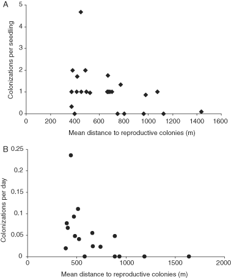

**Figure 2**

Open in figure viewer[PowerPoint](https://resjournals.onlinelibrary.wiley.com/action/downloadFigures?id=f2&doi=10.1111%2Fj.1365-2311.2010.01222.x)

(A) Colonisation frequencies by foundress queens in naturally occurring seedlings as number of colonisations per seedling in a site; and (B) in 17 experimental plots as colonisation per day in relation to the mean distance to colonies potentially containing sexuals.

### Genetic differentiation of C. decamera

DNA was isolated from 200 foundress queens (147 queens from naturally occurring seedlings, including from several dead queens, and 53 from seedlings in experimental plots) and from 73 workers from 20 potential mother colonies of *C. decamera*. One hundred and ninety-four queens and 69 workers were successfully genotyped for five loci. Among those 194 queens and 1 worker each from the 20 potential mother colonies, the probability that two genotypes are identical was P<sub>ID</sub> = 8.073e<sup>−6</sup> (unbiased P<sup>ID</sup> over all loci). Tests for HWE were performed on foundress queens only to ensure that individuals of the same generation were sampled. Foundress queens were separated into subpopulations according to sampling sites they were found in (10 sampling sites >5 individuals within the tree-fall gap). Of the 50 tests performed (5 loci × 10 subpopulations) 10 showed significant deviation from HWE (heterozygote deficiency) before, and only one after Bonferroni correction (corrected *P*-level 0.001). In 2 of the 10 sites, three loci each showed significant deviation from HWE. Ca12 showed significant heterozygote deficiency in 4 of 10 subpopulations, Crem6_2b in 3 of the 10 subpopulations and all other loci in one. Significant linkage disequilibrium was detected in 10 out of 100 tests performed (10 combinations of loci × 10 subpopulations).

Genetic differentiation for *C. decamera* was calculated for 157 queens from 10 subpopulations [sampling sites containing at least five individuals (16 ± 15 individuals mean ± SD)]. Minimum distance between subpopulations was 55 m and maximum distance was 2280 m (752 ± 539 m). Global F<sub>ST</sub> was 0.041 and differed significantly from zero (permutation test, 1000 permutations, mean permutation value = 7.4E<sup>−005</sup>, *P* < 0.001). F<sub>IS</sub> was 0.096 and also deviated significantly from zero (permutation test, *P* < 0.001) (Table 3). Individuals from subpopulation 2 showed highest pairwise F<sub>ST</sub> values compared with all other subpopulations (0.15 ± 0.04; Table 4). Of five individuals in this subpopulation, three were assigned to a group of full sibs in the analysis for distribution of full sibs (see below). When this subpopulation was excluded from the analysis, F<sub>ST</sub> was still significant with 0.034 (permutation test, 1000 permutations, mean permutation value = 1.7E<sup>−005</sup>, *P* < 0.001). There was no correlation between spatial distance and genetic distance (test of isolation by distance; 2000 permutations; a = −0.157; b = 0.033; *P* = 0.116) based on the 10 subpopulations.

Table 3. Global F-statistics for 157 foundress queens, distributed over 10 naturally occurring subpopulations in primary forest.

[output not shown]

- Asterisks indicate significant results of permutation tests with 1000 permutations, ****P* < 0.001.

Table 4. Pairwise F<sub>ST</sub> values (upper semi-matrix) and pairwise distances in metres (lower semi-matrix) of 157 foundress queens of 10 naturally occurring subpopulations with more than 5 foundress queens in primary forest.

| Subpopulation | 1 | 2 | 3 | 4 | 5 | 6 | 7 | 8 | 9 | 10 |
| --- | --- | --- | --- | --- | --- | --- | --- | --- | --- | --- |
| 1 | — | 0.118 | 0.031 | 0.061 | 0.062 | 0.022 | 0.088 | 0.046 | 0.056 | 0.060 |
| 2 | 655 | — | 0.117 | 0.127 | 0.156 | 0.103 | 0.233 | 0.168 | 0.163 | 0.179 |
| 3 | 550 | 1075 | — | 0.050 | 0.032 | 0.001 | 0.039 | 0.014 | 0.017 | 0.034 |
| 4 | 584 | 578 | 657 | — | 0.051 | 0.040 | 0.093 | 0.056 | 0.040 | 0.059 |
| 5 | 803 | 1378 | 312 | 963 | — | 0.015 | 0.050 | 0.018 | 0.009 | −0.013 |
| 6 | 619 | 1139 | 69 | 703 | 260 | — | 0.004 | 0.001 | 0.009 | 0.013 |
| 7 | 603 | 1100 | 67 | 651 | 313 | 55 | — | −0.009 | 0.064 | 0.027 |
| 8 | 690 | 1227 | 153 | 791 | 173 | 90 | 140 | — | −0.004 | 0.007 |
| 9 | 761 | 1209 | 234 | 707 | 336 | 183 | 168 | 196 | — | −0.001 |
| 10 | 1925 | 2282 | 1389 | 1708 | 1260 | 1325 | 1329 | 1278 | 1165 | — |

### Direct estimate of dispersal distances of foundress queens

Foundress queens collected from seedlings (*n* = 194; from naturally occurring hosts and the colonisation experiment) and workers (*n* = 69) from potential reproductive colonies of *C. decamera* (*n* = 20) were assigned to groups of full sibs based on their multilocus genotypes. The mean number of families obtained was 63 ± 0.5. Thus, there must have been at least 63 alate producing reproductive colonies of *C. decamera* in the primary forest, meaning only about a third of these had been found along the trails with the rest probably being scattered over the forest interior.

Twenty-one queens could be assigned unambiguously to 11 respective mother colonies. Minimum dispersal distance was 10 m and maximum distance was 1100 m (470 ± 310 m mean ± SD). Queens from the same reproductive colony sometimes dispersed in the same but also in very different directions (Fig. 3). Forty queens could not be assigned as a full sib to any of the other queens. One hundred and fifty-four individuals were assigned to groups with at least one other full sib (3.6 ± 2.0), resulting in 281 full sib-pairs. A high proportion of full sib pairings (34%) were found within the same site. The maximum distance between full sibs was 2280 m (360 ± 450 m mean ± SD). Spatial autocorrelation showed that genotypes of foundresses were significantly more similar than expected at random at distances lower than approximately 550 m and less similar at distances exceeding 620 m (Fig. 4).

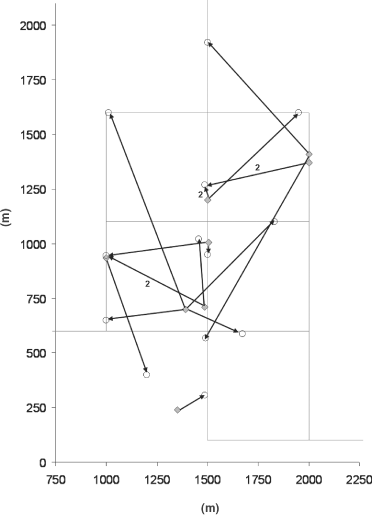

**Figure 3**

Open in figure viewer[PowerPoint](https://resjournals.onlinelibrary.wiley.com/action/downloadFigures?id=f3&doi=10.1111%2Fj.1365-2311.2010.01222.x)

Dispersal distances and directions of foundress queens (*n* = 13 sites with 21 queens) which were unambiguously assigned to their natal colonies (*n* = 8 sites with 11 colonies) based on multilocus genotypes. Black lines connect natal colonies (diamonds) with seedlings (circles) where foundresses were collected from. Numbers next to lines indicate the number of ant queens that dispersed between these sites when more than one foundress has dispersed between sites. Gray lines show trails of the West Grid.

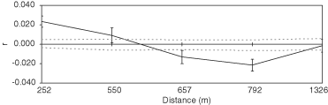

**Figure 4**

Open in figure viewer[PowerPoint](https://resjournals.onlinelibrary.wiley.com/action/downloadFigures?id=f4&doi=10.1111%2Fj.1365-2311.2010.01222.x)

Correlogram of spatial autocorrelation of foundress queens within the study area (*n* = 194). Distance classes contain even number of foundresses. Continuous line: autocorrelation coefficient *r*; dotted lines: upper and lower 95% confidence limits. When *r* exceeds the confidence limits genotypes are more similar (or less similar respectively) than expected from a random distribution.

## Discussion

Nonetheless, the estimates of average (and maximal) dispersal distances may be too small as only 20 out of an estimated 63 reproductive colonies releasing foundress queens were mapped within the study site. The undetected colonies may have been scattered within the study area (West-grid, Fig. 1A) in dense parts of the forest that were hardly accessible. If foundresses originated from the centre of the West-grid the estimation of dispersal distances would not be greatly altered. However, if foundresses originated from trees outside the study area, the frequent occurrence of long-distance dispersal events cannot be excluded. In this case dispersal distances may have been considerably underestimated. The maximum dispersal distance of >1 km detected in this study indicates the potential for longer flight distances e.g. in parts of the forest with a lower density of seedlings than in the area of the West-grid. In addition, the increase in the number of available seedlings within experimental sites may have biased dispersal of foundresses in the colonisation experiment towards shorter dispersal distances.

A decrease of colonisation frequency with increasing distance between reproductive colony and host seedling has also been observed in other ant–plant associations (Vasconcelos, 1993; Yu & Davidson, 1997; Yu *et al.*, 2004; Debout *et al.*, 2009). Vasconcelos (1993) detected a significant decrease in the colonisation frequency of two ant species associated with the same host at distances of below 150 m to reproductive colonies.

Significant genetic substructuring among patches on a scale of several hundred metres has also been observed in other obligate plant-ants, such as *Allomerus octoarticulatus* var. *demerarae* (Szilagyi *et al.*, 2009) and *Petalomyrmex phylax* on *Leonardoxa a. africana* (Leotard *et al.*, 2008). A similar genetic population structure of the host plant and ant partner in the latter association suggested that the population structure reflected historical colonisation dynamics, underscoring the importance of interdependence among ant and plant partners in shaping the genetic population structure of both symbionts (Leotard *et al.*, 2008). The highly specialised nesting requirements of obligatory social parasites that require host colonies of specific ant species for reproduction (Trontti *et al.*, 2006) or specific breeding systems where one sex shows very limited dispersal only (Chapuisat *et al.*, 1997; Doums *et al.*, 2002; Oberstadt & Heinze, 2003; Berghoff *et al.*, 2008) have also been discussed as a factor responsible for strong differentiation at small spatial scales.

The costs of dispersing over longer distances (Murrell *et al.*, 2002) as well as the strong dependency of foundress queens on hosts, may promote short dispersal distances and thus indirectly female philopatry, leading to pronounced genetic substructuring on small spatial scales. Limited dispersal of queens would explain the observed pattern of strongly diverged mitochondrial DNA at regional scales in the *Macaranga*-associated *Crematogaster* (*Decacrema*) species (Feldhaar *et al.*, 2003a; Quek *et al.*, 2007).

Currently it is not known whether the dispersal distances found in this study generally apply to *C. decamera*. Dispersal distances of foundress queens may vary as a plastic response (within limits) to a given spatial distribution of hosts. Thus, when suitable and uncolonised hosts are abundant as is nowadays found at logged forest sites, foundresses may disperse over shorter distances than found in this study (H. Feldhaar *et al.*, unpublished). In contrast, dispersal distances need to be larger when hosts are scarce and patchily distributed as in dense forests with few gaps. Variability in the strength of intra- and interspecific competition of obligate plant–ants will also strongly influence the number of hosts available for colonisation and thus dispersal distance. Differences in dispersal ability between obligate plant–ant species may often facilitate coexistence of species pairs competing for the same host species (Yu *et al.*, 2001, 2004; Palmer *et al.*, 2003; Debout *et al.*, 2009). Larger dispersal distances enable a species to colonise more remote host plant seedlings and to escape from competition with other ant species. However, such larger dispersal distances have been shown to come at the cost of lowered fecundity and higher mortality of incipient colonies (Yu *et al.*, 2004; Debout *et al.*, 2009), and such a trade-off is also likely to occur intraspecifically. The spatial distribution of hosts may be altered from the ant's point of view by broadening the host spectrum or staying a generalist. When switching to closely related or phenotypically similar host species (Davidson & McKey, 1993; Feldhaar *et al.*, 2003a), the number of available hosts and the number of patches containing hosts can be increased and may enable the ants to have a wider and less patchy distribution.

In conclusion, the interdependency of *C. decamera* with *M. hypoleuca* and the limited dispersal ability of the partner ant may render this mutualism highly susceptible to habitat fragmentation (Bruna *et al.*, 2005). Disruption of the natural habitat and reduction of population sizes of both partners may lead to a negative feedback loop where plants are able to colonise empty habitat patches, but local ant partners cannot follow as a result of a greater limitation in their dispersal distances. This might adversely affect the ecological role of this important pioneer plant in forest regeneration processes, and may ultimately result in different coevolutionary trajectories of the association in regions which have become more isolated.

## Acknowledgements

We thank two anonymous reviewers for their comments that helped to improve this manuscript. We are very grateful to Sophie Armitage for improving the English and suggestions on the manuscript. This work was supported by Deutsche Forschungsgemeinschaft (grants Fe631/1-1, Fe631/1-2 and Fi606/5) within priority program SPP 1127 ‘Adaptive Radiations'. Permission to conduct research in Malaysia was kindly granted by the Economic Planning Unit (EPU) of the Prime Minister's Office, Kuala Lumpur and EPU in Kota Kinabalu, Sabah, as well as the Danum Valley Management Committee. We thank our counterparts and colleagues in Malaysia for their cooperation and support, especially Prof. Datin Dr. Maryati Mohamed and Dr Glen Reynolds.

## Citing Literature

[Volume35, Issue5](https://resjournals.onlinelibrary.wiley.com/toc/13652311/2010/35/5)

October 2010

Pages 662-671